# # Loans, Bankers and Delinquencies by Ken Musante, DAND Student

# Bivariate Analysis

As stated at the outset, there are a lot of variables in this data set. I explored a number of them trying to ascertain a link between charge-offs or Gross Principal Loss and variables within our data set.

### Interesting relationships between the other features

I thought there would be a clear relationship between the percentage of the loan funded and Charge-offs. There was not. Likewise, I believed that if a borrower had a loan partially funded from a friend, then they would be less likely to default because their friend would lose money.  
This relationship did not hold.

I believed there would be less chance of a charge-off if the borrower was a homeowner. This too proved invalid. This might be due to the Great Recession when home values dipped below the loan value for many home owners.

### Strongest relationship found?

# Multivariate Plots Section

Clearly we need to examine 1-Debt Consolidation, 3-Business and 7-Other loans more deeply.

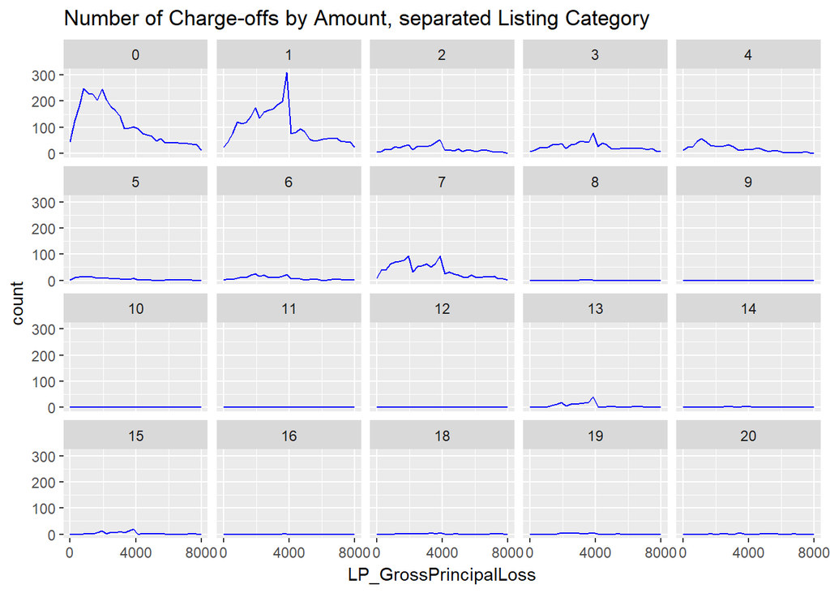

Higher Stated Mo. Income seemed to get a Lower APR– makes sense.

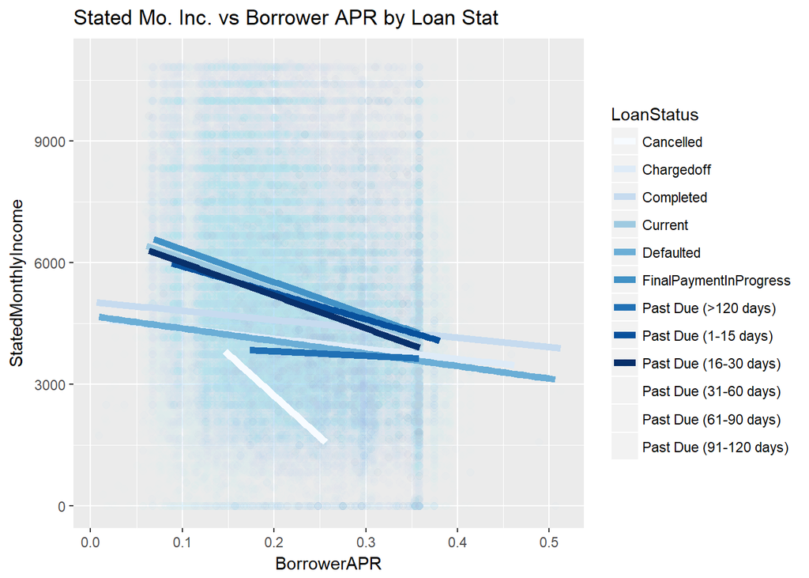

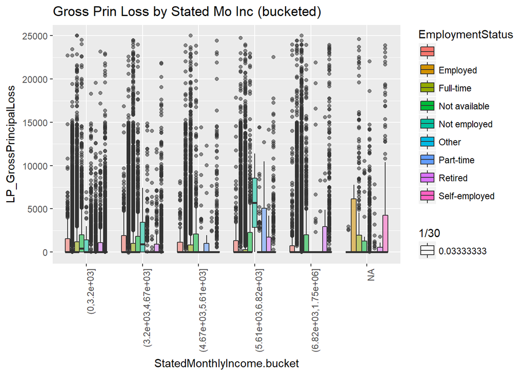

Drop all graphs except 1, 3 and 7 and include Employment Status

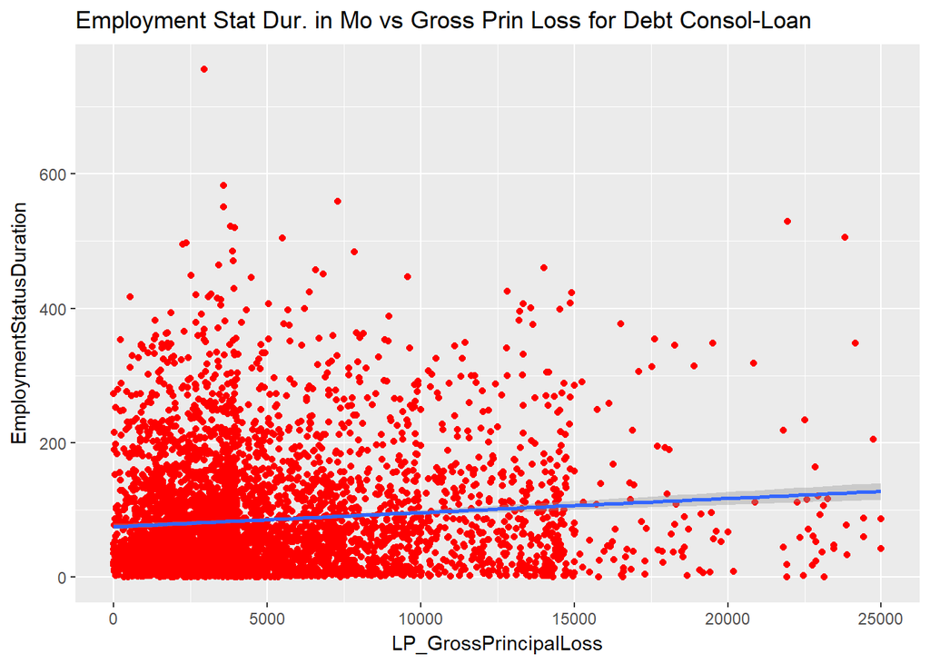

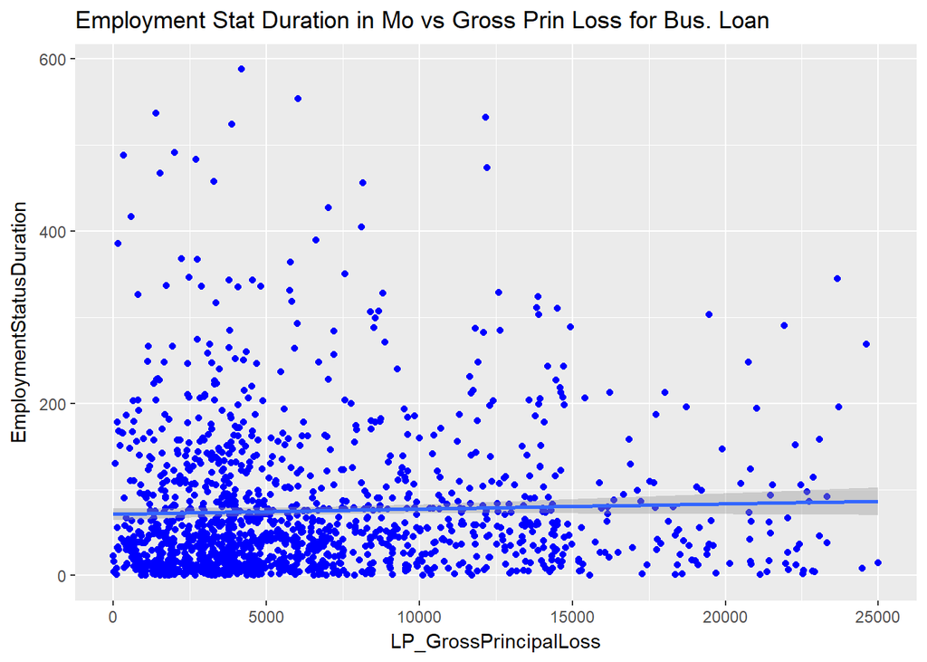

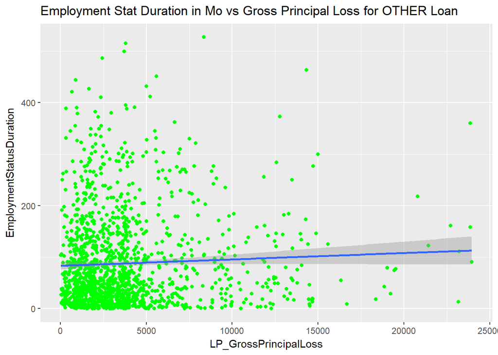

From the above three graphs, which separate out Employment Status Duration for each of the more problematic ListingCategories, there does not appear to be a clear reason to pair Employment Status Duration with ListingCategories.

```
##
##  Pearson's product-moment correlation
##
## data:  loans$LP_GrossPrincipalLoss and loans$DebtConsolodation
## t = Inf, df = 113940, p-value < 2.2e-16
## alternative hypothesis: true correlation is not equal to 0
## 95 percent confidence interval:
##  1 1
## sample estimates:
## cor
##   1
```

```
##
##  Pearson's product-moment correlation
##
## data:  loans$LP_GrossPrincipalLoss and loans$BusinessLoan
## t = Inf, df = 113940, p-value < 2.2e-16
## alternative hypothesis: true correlation is not equal to 0
## 95 percent confidence interval:
##  1 1
## sample estimates:
## cor
##   1
```

```
##
##  Pearson's product-moment correlation
##
## data:  loans$LP_GrossPrincipalLoss and loans$OtherLoan
## t = Inf, df = 113940, p-value < 2.2e-16
## alternative hypothesis: true correlation is not equal to 0
## 95 percent confidence interval:
##  1 1
## sample estimates:
## cor
##   1
```

Look at amount of loss by Big 3 Loss Categories It appears OTHER may have more loans but Debt Consolodation and Business Loan have greater losses.

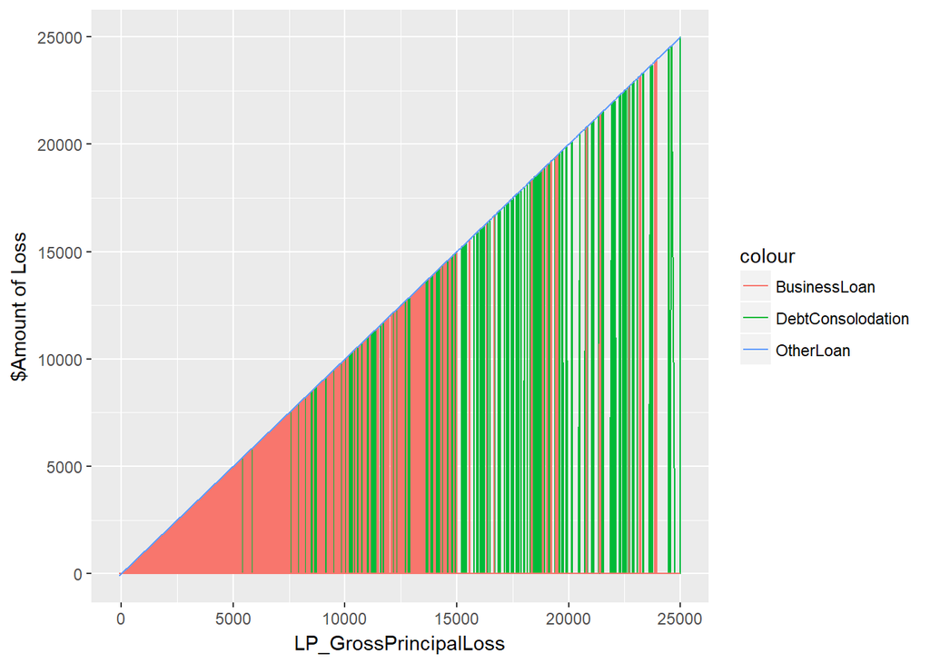

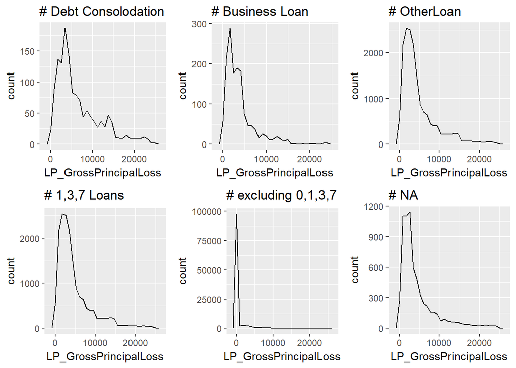

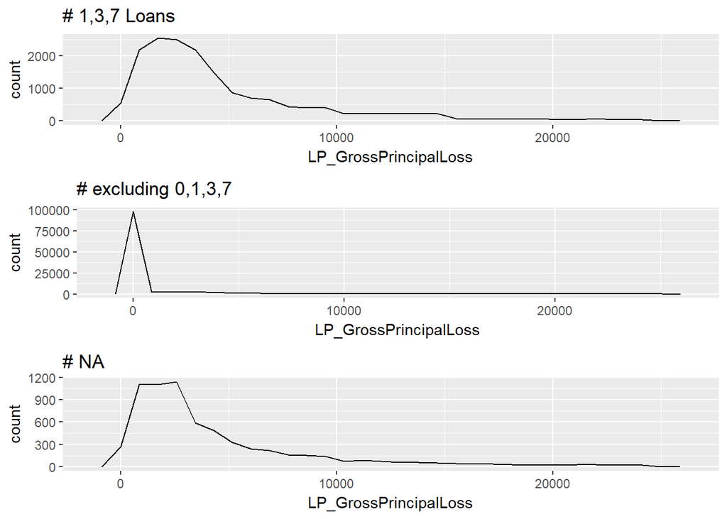

```
##
##  Pearson's product-moment correlation
##
## data:  loans$ThreeLoanTypes and loans$LP_GrossPrincipalLoss
## t = 976.6, df = 113940, p-value < 2.2e-16
## alternative hypothesis: true correlation is not equal to 0
## 95 percent confidence interval:
##  0.9445161 0.9457554
## sample estimates:
##       cor
## 0.9451391
```

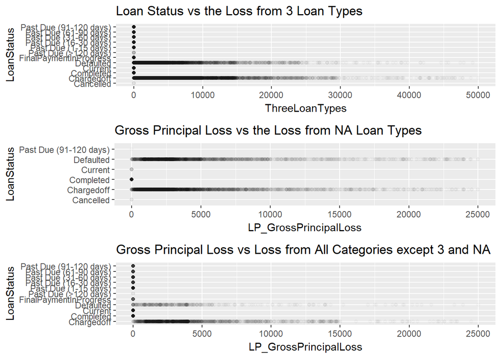

# Multivariate Analysis

### It was surprising to me that none of the other variables I looked at were

### strongly correlated with Charge-offs.

None of the other variables had a significant correlation with Charge-offs except EmploymentDuration in months however that did not seem to add anything when adding it to ListingCategory..numeric.

### I did not create a mathematical model but I do have a conclusion.

Do not make loans for Debt Consolidation, Business or Other purposes. Certainly more work would be needed to determine the repercussions of this decision but on the surface those loan types should be avoided.

Also, while I do not know the reason for the lack of correlation of the other variables I studied, I suspect it could be related to the Great Recession where all loan types failed at a much higer rate and home prices fell far underwater.

# Final Plots and Summary

Warnings and messages not set to ‘False’ intentionally as it appears Udacity would like them left that way.

### Plot One

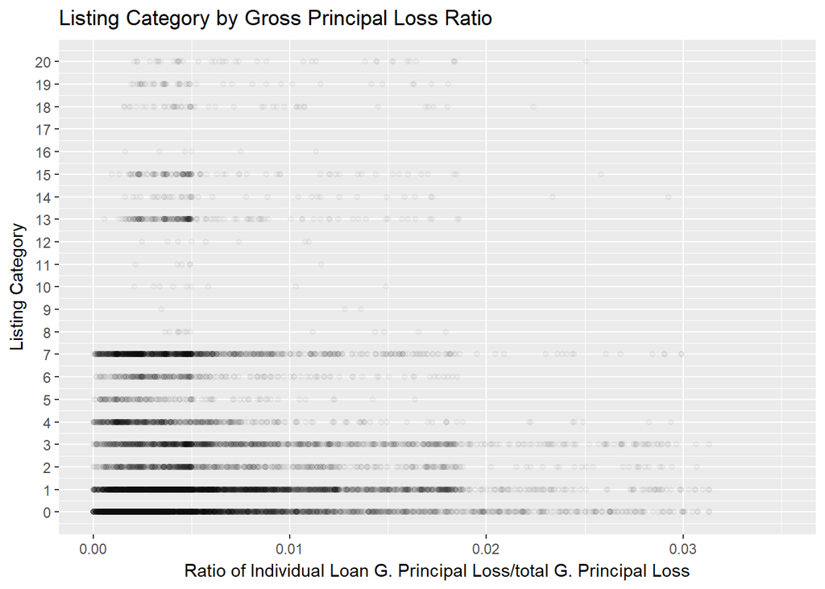

### Description One

You can see from the darkness of the line next to the 4 above listing categories that not only do they have the most data points but those data points tend to be on the larger end of the x Axis as well.

Each point was a loan which was charged off and each represented a % of the total charged-off

### Plot Two

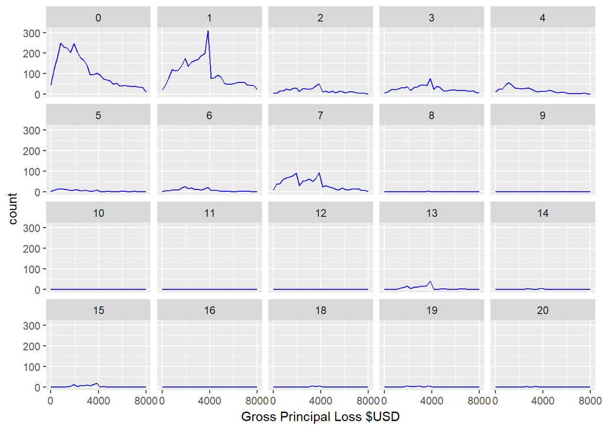

```
## $title
## [1] "Number of Charge-offs by Amount separated by Listing Category"
##
## $subtitle
## NULL
##
## attr(,"class")
## [1] "labels"
```

### Plot Three

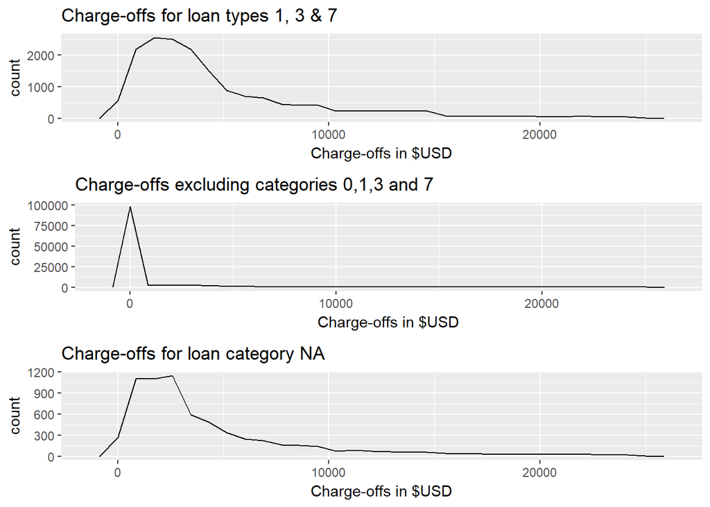

### Description Three

I wanted to illustrate on a larger plot some of the information expressed in plot 2. Hence I pulled out the 3 categories most responsible for the charge-offs and plot it next to the plots illustrating the charge-offs from all other loan types as well as the charge-offs from loan type NA. I separated out NA because it is not a loan type upon which we can base a decision as we do not have the data.

Regardless, I believe this graph accurately reflects the loan types which are the culprits for the charge-offs. ——

# Reflection

I went down a lot of rabbit holes to no where. I should have looked at the data more thoroughly first and recognized that many of the variables had too many N/A’s or were zeroed out to be useful. Additionally, it was frustrating to find so many of the variables were not correlated to Charge-offs. This was not frustrating but made my task more difficult. It was very surprising, for example, that the Charge-offs were not correlated to the borrowers CreditScore.

It was interesting too that I could get a feel for the loan portfolio from only the data. I know for example that this is a high margin, higher risk and higher return type portfolio.

Finally, manipulating the data so that we get a count when we want the number of items in a column and amount when we want to add the values in a column can be very difficult.

If I was to provide input to this lender, and had more time to so so I would want to try to find out what else correlates with the three Listing Categories which would identify a probability for a charge-off. For example, if I was to look at OnTimeProsper- Payments or CurrentDelinquencies, might these have have strengthened my correlation to better identify which loans would likely charge-off. Further, I would have liked to further explore loan amounts within my stated hypothesis. For example, would a smaller loan or larger loan more likely lead to a charge- off within the loan categories identified?

Please contact me at kenm@eurekapayments.com for further questions or comments.